# final_report

**Leng Her**

*11/30/2024*

## Introduction

In this analysis, we aim to find trends in popular music reflected in the Billboard Year-End Hot 100 Songs for the years 2018 through 2023. By examining the top-charting songs from this period, we want to explore the similarities and differences between songs by clustering their audio features, extracted from the Spotify API. The audio features include: Danceability, Energy, Loudness, Speechiness, Acousticness, Intrumentalness, Livenes, Valence, and Tempo (Each one will be explained further in the About Data Section).

This time frame was chosen due to a couple of reasons, one mainly being the API call limit restraint. More details about the API constraints can be found in the Spotify API documentation. Furthermore, the period from 2018 to 2023 captures a shift in the music industry influenced by streaming platforms, and social media trends (e.g., TikTok) that impacted music consumption habits. Our analysis will solely focus on the audio features mentioned to identify trends in the types of songs that consistently rank in the top 100.

Through this analysis we aim to answer the following key questions:

- What similarities and differences can be observed between songs based on clusters of characteristics?
- Are there observable trends in audio features of songs that make it to the Year-End Hot 100 charts?
- How do songs within clusters vary across different years?
- Can we identify any significant patterns in the types of songs that dominate the charts based solely on their aduio features?

**Quick References**

- https://developer.spotify.com/documentation/web-api/reference/get-audio-features
- https://developer.spotify.com/documentation/web-api
- https://www.billboard.com/charts/year-end/hot-100-songs/
- https://www.ibm.com/topics/k-means-clustering
- https://www.geeksforgeeks.org/k-means-clustering-introduction/
- https://scikit-learn.org/1.5/auto_examples/cluster/plot_kmeans_silhouette_analysis.html
- https://medium.com/@cmukesh8688/silhouette-analysis-in-k-means-clustering-cefa9a7ad111
- https://scikit-learn.org/1.5/modules/generated/sklearn.cluster.KMeans.html
- https://en.wikipedia.org/wiki/Silhouette_(clustering)

## About The Data

This analysis relies on two primary data sources: the Billboard Year-End Hot 100 Songs and audio features obtained from the Spotify API. Together these datasets provide a view of the top-charting songs and their underlying musical characteristics. Below, we explain the data features in detail and outline the methods used to gather this data.

`Data Features`

The audio features extracted from the Spotify API include:

- **Danceability**: A meaure (0.0 to 1.0) of how suitable a track is for dancing, considering tempo, rhythm stability, beat strength, and overall regularity. Higher values indicate higher suitability for dance.
- **Energy**: A measure of intensity and activity, ranging from 0.0 (low intensity) to 1.0 (high intensity). Energectic tracks often feel fast and dynamic.
- **Loudness**: The overall loudness of a track, measured in decibles (dB). Values typically range from -60 to 0 dB, where the higher values indicate louder tracks.
- **Speechiness**: A measure 0.0 to 1.0 of the presence of spoken words in a track. Values closer to 1 indicate speech-dominant content (e.g., podcasts or spoken word).
- **Acousticness**: A confidence measure 0.0 to 1.0 indicating whether a track is acoustic. Higher values represent higher confidence that the track is acoustic.
- **Instrumentalness**: Predicts whether a track contains no vocals. Values above 0.5 indicate a higher likelihood of being instrumental.
- **Liveness**: Detects the presence of an audience in the recording, with values above 0.8 suggesting a strong likelihood that the track was recorded live.
- **Valence**: A measure 0.0 to 1.0 of musical positiveness of a track. Higher values indicate more positive and uplifting sounds.
- **Tempo**: The estimated speed or pace of a track, measured in beats per minute (BPM).

Each of these features provide insights into the musical characteristics of the songs, allowing us to cluster and analyze them based on their features. More information about each feature can be found in the [Spotify API Documentation](https://developer.spotify.com/documentation/web-api/reference/get-audio-features)

`Data Collection`

1. **Billboard Year-End Data**:
   - The Billboard Year-End Hot 100 Songs data was gathered using web scraping techniques. Each year's chart was accessed through the Billboard website and details (e.g., rank, title, and artist) were extracted using Python libraries.

   *Code Sample:*

```
import requests
from bs4 import BeautifulSoup
import pandas as pd

# Scrape data from billboard website

def scrape_billboard_year(year):
    """Scrape Billboard Hot 100 for a specific year

    Args:
        year (int): Year we want to extract data from

    Returns:
        temp_df (pandas.DataFrame): Dataframe containing the stripped information from the website, namely:
            Rank,Song,Artist
    """
    print(f"\nScraping year {year}...")

    url = f'https://www.billboard.com/charts/year-end/{year}/hot-100-songs/'

    headers = {
        'User-Agent': 'Mozilla/5.0 (Windows NT 10.0; Win64; x64) AppleWebKit/537.36 (KHTML, like Gecko) Chrome/91.0.4472.124 Safari/537.36'
    }


    response = requests.get(url, headers=headers)
    soup = BeautifulSoup(response.text, 'html.parser')

    # Reference: https://stackoverflow.com/questions/71461576/beautiful-soup-find-function-returning-none-even-though-element-exists-and-fin
    entries = soup.find_all('div', class_='o-chart-results-list-row-container')

    ranks = []
    songs = []
    artists = []

    for entry in entries:
        try:
            #rank from first span with class c-label
            rank = entry.find('span', class_='c-label').text.strip()

            #song title
            song_element = entry.find('h3', class_='c-title')
            song = song_element.text.strip() if song_element else "N/A"

            # looking specifically for the artist span
            # Updated to find the correct span for artist
            artist_element = entry.find('span', class_='c-label',
                                     attrs={'for': 'chart-element-artist'})
            if not artist_element:
                artist_element = entry.select('li.o-chart-results-list__item span.c-label:not([for])')[1]
            artist = artist_element.text.strip() if artist_element else "N/A"

            #clean extra whitespace and formatting
            rank = ''.join(filter(str.isdigit, rank)) #make sure rank is a digit
            song = ' '.join(song.split())
            artist = ' '.join(artist.split())

            ranks.append(rank)
            songs.append(song)
            artists.append(artist)

        except AttributeError as e:
            print(f"Error processing entry: {e}")
            continue
        except IndexError as e:
            print(f"Error finding artist: {e}")
            continue

    temp_df = pd.DataFrame({
        'Rank': ranks,
        'Song': songs,
        'Artist': artists,
        'Year': year
    })

    temp_df['Rank'] = pd.to_numeric(temp_df['Rank'])
    temp_df = temp_df.sort_values('Rank')

    print(f"Found {len(temp_df)} songs for year {year}")

    return temp_df
```

2. **Spotify API**:
   - Audio features for each song were retrieved using Spotiy Web API. For this, the Spotify track features were obtained by matching the song titles and artist from the Billboard dataset to the Spotify database for each song.
   - The Spotify API provides a set of audio features for each track. API calls were made using Python libraries like **spotipy**, and the data was structured and saved for further analysis.
   - Due to API call limitations, the analysis focuses on the years 2018 through 2023, ensuring efficient data collection while adhering to the [Spotify Rate Limits](https://developer.spotify.com/documentation/web-api/concepts/rate-limits).

   *Code sample:*

   ```
   sp = spotipy.Spotify(
       client_credentials_manager=SpotifyClientCredentials(
           client_id=CLIENT_ID,
           client_secret=CLIENT_SECRET
       ),
       requests_timeout=10
   )

   print("\nBillboard data collected. Starting Spotify feature extraction...")

   # Initialize columns
   spotify_columns = ['spotify_id', 'spotify_name', 'spotify_artist', 'spotify_album',
                   'release_date', 'danceability', 'energy', 'key', 'loudness',
                   'mode', 'speechiness', 'acousticness', 'instrumentalness',
                   'liveness', 'valence', 'tempo', 'duration_ms', 'time_signature']

   for col in spotify_columns:
       billboard_df[col] = None

   billboard_df['spotify_error'] = False # indicate if there was an error; intialize to False

   #process each song
   print("\nPart 2: Getting Spotify features...")
   total_songs = len(billboard_df)

   for idx, row in billboard_df.iterrows():
       try:
           print(f"Processing {row['Song']} by {row['Artist']} ({idx + 1}/{total_songs})")
           ... Code continues
       except:
           ... Code continues
       # Sleep to respect rate limits
       time.sleep(10)

   # Final cleanup
   final_df = billboard_df.copy()
   ```

`Data Challenges`

Several challenges arose during data collection and preprocessing:

- **Matching Billboard and Spotify Data**: Song titles and artist names often differed due to discrepancies in naming conventions, such as Billboard including multiple artists with terms like Featuring, With, Duet With, X, or x, causing errors. This resulted in a 78% success rate for retrieving data initially. To address this, we cleaned the artist data by extracting only the first artist's name, which improved the success rate to 98%.
- **Rate Limits**: Spotify's API call limits made it so we had to implement delays and batching to avoid errors. Spotify does have the option to make 1 API call for 100 tracks and retrieve the information only if we have the Spotify ID which can be manually extracted from each song in the WEB Address. Because this would be a lot of manual labor we decided to go with the automated method with longer delays allowing us to get our features. Future enhancements would be to collect the data in batches and store the Spotify ID for later use and more efficient API calls.
- **Incomplete Data**: Some songs from the Billboard charts were not avaliable initially on Spotify leading to some gaps in the dataset. This problem was addressed by collecting the missing songs and their respective aritst and gathering the Spotify ID manually then querying it against the Spotify Database via API.

Despite these challenges, the final dataset provides a set of features for clustering and analyzing trends in popular music.

*Data Example:*

```python
import pandas as pd
df = pd.read_csv('O:/Univseristy Of St. Thomas DS/Fall 2024/Data Analytics and Vizualization/Project/feed/dataset.csv', delimiter='\t')

df.head(10)
```

|  | Rank | Song | Artist | Year | spotify_id | spotify_name | spotify_artist | spotify_album | release_date | danceability | ... | loudness | mode | speechiness | acousticness | instrumentalness | liveness | valence | tempo | duration_ms | time_signature |
| --- | --- | --- | --- | --- | --- | --- | --- | --- | --- | --- | --- | --- | --- | --- | --- | --- | --- | --- | --- | --- | --- |
| 0 | 1 | Levitating | Dua Lipa | 2021 | 5nujrmhLynf4yMoMtj8AQF | Levitating (feat. DaBaby) | Dua Lipa | Future Nostalgia | 3/27/2020 | 0.702 | ... | -3.787 | 0 | 0.0601 | 0.00883 | 0.000000 | 0.0674 | 0.915 | 102.977 | 203064 | 4 |
| 1 | 2 | Save Your Tears | The Weeknd & Ariana Grande | 2021 | 5QO79kh1waicV47BqGRL3g | Save Your Tears | The Weeknd | After Hours | 3/20/2020 | 0.679 | ... | -5.487 | 1 | 0.0309 | 0.02120 | 0.000012 | 0.5430 | 0.644 | 118.049 | 215627 | 4 |
| 2 | 3 | Blinding Lights | The Weeknd | 2021 | 0VjIjW4GlUZAMYd2vXMi3b | Blinding Lights | The Weeknd | After Hours | 3/20/2020 | 0.513 | ... | -5.940 | 1 | 0.0598 | 0.00143 | 0.000095 | 0.0897 | 0.334 | 171.001 | 200040 | 4 |
| 3 | 4 | Mood | 24kGoldn Featuring iann dior | 2021 | 4jPy3l0RUwlUI9T5XHBW2m | Mood (feat. iann dior) | 24kGoldn | El Dorado | 3/26/2021 | 0.701 | ... | -3.671 | 0 | 0.0361 | 0.17400 | 0.000000 | 0.3240 | 0.732 | 91.007 | 140533 | 4 |
| 4 | 5 | Good 4 U | Olivia Rodrigo | 2021 | 4ZtFanR9U6ndgddUvNcjcG | good 4 u | Olivia Rodrigo | SOUR | 5/21/2021 | 0.563 | ... | -5.044 | 1 | 0.1540 | 0.33500 | 0.000000 | 0.0849 | 0.688 | 166.928 | 178147 | 4 |
| 5 | 6 | Kiss Me More | Doja Cat Featuring SZA | 2021 | 3DarAbFujv6eYNliUTyqtz | Kiss Me More (feat. SZA) | Doja Cat | Planet Her | 6/25/2021 | 0.764 | ... | -3.463 | 1 | 0.0284 | 0.25900 | 0.000089 | 0.1200 | 0.781 | 110.970 | 208667 | 4 |
| 6 | 7 | Leave The Door Open | Silk Sonic (Bruno Mars & Anderson .Paak) | 2021 | 02VBYrHfVwfEWXk5DXyf0T | Leave The Door Open | Bruno Mars | An Evening With Silk Sonic | 11/11/2021 | 0.586 | ... | -7.964 | 1 | 0.0324 | 0.18200 | 0.000000 | 0.0927 | 0.719 | 148.088 | 242096 | 4 |
| 7 | 8 | Drivers License | Olivia Rodrigo | 2021 | 5wANPM4fQCJwkGd4rN57mH | drivers license | Olivia Rodrigo | SOUR | 5/21/2021 | 0.561 | ... | -8.810 | 1 | 0.0578 | 0.76800 | 0.000014 | 0.1060 | 0.137 | 143.875 | 242013 | 4 |
| 8 | 9 | Montero (Call Me By Your Name) | Lil Nas X | 2021 | 1SC5rEoYDGUK4NfG82494W | MONTERO (Call Me By Your Name) | Lil Nas X | MONTERO | 9/17/2021 | 0.593 | ... | -6.725 | 0 | 0.2200 | 0.29300 | 0.000000 | 0.4050 | 0.710 | 178.781 | 137704 | 4 |
| 9 | 10 | Peaches | Justin Bieber Featuring Daniel Caesar & Giveon | 2021 | 4iJyoBOLtHqaGxP12qzhQI | Peaches (feat. Daniel Caesar & Giveon) | Justin Bieber | Justice | 3/19/2021 | 0.677 | ... | -6.181 | 1 | 0.1190 | 0.32100 | 0.000000 | 0.4200 | 0.464 | 90.030 | 198082 | 4 |

10 rows × 22 columns

```python
df.info()
```

```
<class 'pandas.core.frame.DataFrame'>
RangeIndex: 600 entries, 0 to 599
Data columns (total 22 columns):
 #   Column            Non-Null Count  Dtype
---  ------            --------------  -----
 0   Rank              600 non-null    int64
 1   Song              600 non-null    object
 2   Artist            600 non-null    object
 3   Year              600 non-null    int64
 4   spotify_id        600 non-null    object
 5   spotify_name      596 non-null    object
 6   spotify_artist    596 non-null    object
 7   spotify_album     596 non-null    object
 8   release_date      596 non-null    object
 9   danceability      600 non-null    float64
 10  energy            600 non-null    float64
 11  key               600 non-null    int64
 12  loudness          600 non-null    float64
 13  mode              600 non-null    int64
 14  speechiness       600 non-null    float64
 15  acousticness      600 non-null    float64
 16  instrumentalness  600 non-null    float64
 17  liveness          600 non-null    float64
 18  valence           600 non-null    float64
 19  tempo             600 non-null    float64
 20  duration_ms       600 non-null    int64
 21  time_signature    600 non-null    int64
dtypes: float64(9), int64(6), object(7)
memory usage: 103.2+ KB
```

Here we can see some information is missing but they aren't relevant to our analysis so its ok if they are missing. These are missing due to them being a mismatch so manual intervention was introduced to get the remaining data that was needed to complete the anaylsis.

```python
df.shape
```

```
(600, 22)
```

```python
df.describe()
```

|  | Rank | Year | danceability | energy | key | loudness | mode | speechiness | acousticness | instrumentalness | liveness | valence | tempo | duration_ms | time_signature |
| --- | --- | --- | --- | --- | --- | --- | --- | --- | --- | --- | --- | --- | --- | --- | --- |
| count | 600.000000 | 600.00000 | 600.000000 | 600.000000 | 600.000000 | 600.000000 | 600.000000 | 600.000000 | 600.000000 | 600.000000 | 600.000000 | 600.000000 | 600.000000 | 600.000000 | 600.00000 |
| mean | 50.500000 | 2020.50000 | 0.686472 | 0.621058 | 5.166667 | -6.322142 | 0.631667 | 0.112944 | 0.217534 | 0.004630 | 0.170424 | 0.496079 | 121.547715 | 198904.961667 | 3.95000 |
| std | 28.890155 | 1.70925 | 0.138649 | 0.148516 | 3.583801 | 2.081380 | 0.482755 | 0.110031 | 0.225051 | 0.042079 | 0.120345 | 0.216676 | 29.257183 | 40023.483792 | 0.31251 |
| min | 1.000000 | 2018.00000 | 0.247000 | 0.084000 | 0.000000 | -17.843000 | 0.000000 | 0.023200 | 0.000307 | 0.000000 | 0.021500 | 0.038500 | 64.934000 | 80927.000000 | 1.00000 |
| 25% | 25.750000 | 2019.00000 | 0.591000 | 0.523000 | 2.000000 | -7.439000 | 0.000000 | 0.039600 | 0.038300 | 0.000000 | 0.095625 | 0.339750 | 97.037000 | 176201.000000 | 4.00000 |
| 50% | 50.500000 | 2020.50000 | 0.696500 | 0.624000 | 5.000000 | -6.013500 | 1.000000 | 0.061500 | 0.137500 | 0.000000 | 0.122000 | 0.488000 | 120.044000 | 198121.000000 | 4.00000 |
| 75% | 75.250000 | 2022.00000 | 0.789250 | 0.730000 | 8.000000 | -5.002500 | 1.000000 | 0.145000 | 0.321000 | 0.000006 | 0.200000 | 0.662250 | 141.981250 | 216587.750000 | 4.00000 |
| max | 100.000000 | 2023.00000 | 0.970000 | 0.965000 | 11.000000 | -1.746000 | 1.000000 | 0.619000 | 0.978000 | 0.657000 | 0.790000 | 0.956000 | 205.863000 | 613027.000000 | 5.00000 |

```python
df["time_signature"].value_counts()
```

```
4    564
3     27
5      6
1      3
Name: time_signature, dtype: int64
```

In the case of time_signature its mostly 4 so we can safetly remove that feature without it impacting the clustering as well as instrumentalness which really only ranges from 0 to 0.657 with the first two quartiles being 0

## Exploratory Data Analysis (EDA)

In this section we aim to explore and understand our dataset while preparing it for our unsupervised clustering model K-means clustering. More information on this clustering method can be found above in the References section.

```python
import matplotlib.pyplot as plt
import matplotlib.cm as cm
import seaborn as sns
from sklearn.cluster import KMeans
from sklearn.metrics import silhouette_score, silhouette_samples
from sklearn.preprocessing import StandardScaler
import numpy as np
from sklearn.decomposition import PCA
```

```python
# Example in Python
df['duration_unicode'] = df['duration_ms'].apply(
    lambda x: 0 if x < 176201 else 1 if x <= 216588 else 2
)
```

Short (0): Songs with durations less than Q1 (176,201 ms = 2.936683333 Min)

Medium (1): Songs between Q1 (176,201 ms) and Q3 (216,588 ms = 3.6098 Min).

Long (2): Songs greater than Q3 (216,588 ms).

```python
# Select audio features for correlation analysis
audio_features = ['danceability', 'energy', 'loudness', 'speechiness',
                 'acousticness', 'instrumentalness', 'liveness', 'valence',
                 'tempo', 'duration_unicode']

# Calculate correlation matrix
df[audio_features] = df[audio_features].apply(pd.to_numeric, errors='coerce')
correlation_matrix = df[audio_features].corr()
```

```python
correlation_matrix
```

|  | danceability | energy | loudness | speechiness | acousticness | instrumentalness | liveness | valence | tempo | duration_unicode |
| --- | --- | --- | --- | --- | --- | --- | --- | --- | --- | --- |
| danceability | 1.000000 | -0.000625 | 0.018197 | 0.308652 | -0.286170 | 0.006796 | -0.017870 | 0.240583 | -0.098767 | -0.150167 |
| energy | -0.000625 | 1.000000 | 0.716081 | -0.072893 | -0.489499 | -0.067004 | 0.121108 | 0.364806 | 0.045246 | -0.058182 |
| loudness | 0.018197 | 0.716081 | 1.000000 | -0.130926 | -0.387120 | -0.143382 | 0.036703 | 0.266697 | 0.038245 | -0.053223 |
| speechiness | 0.308652 | -0.072893 | -0.130926 | 1.000000 | -0.178812 | 0.003966 | -0.094087 | -0.047926 | 0.102329 | -0.067002 |
| acousticness | -0.286170 | -0.489499 | -0.387120 | -0.178812 | 1.000000 | 0.087034 | -0.063108 | -0.108152 | -0.078607 | -0.002804 |
| instrumentalness | 0.006796 | -0.067004 | -0.143382 | 0.003966 | 0.087034 | 1.000000 | -0.043446 | -0.103263 | 0.002779 | 0.074331 |
| liveness | -0.017870 | 0.121108 | 0.036703 | -0.094087 | -0.063108 | -0.043446 | 1.000000 | 0.064409 | -0.065932 | -0.018524 |
| valence | 0.240583 | 0.364806 | 0.266697 | -0.047926 | -0.108152 | -0.103263 | 0.064409 | 1.000000 | -0.020536 | -0.198017 |
| tempo | -0.098767 | 0.045246 | 0.038245 | 0.102329 | -0.078607 | 0.002779 | -0.065932 | -0.020536 | 1.000000 | 0.036151 |
| duration_unicode | -0.150167 | -0.058182 | -0.053223 | -0.067002 | -0.002804 | 0.074331 | -0.018524 | -0.198017 | 0.036151 | 1.000000 |

```python
'''
Loop through the correlation matrix and find highly correlated values (greater that 0.5)

We want to remove highly correlated values because they often contain overlapping information, meaning they explain similar patterns of data. So it leads to more redudant data being introduced.
In terms of highly correlated columns in clustering such as K-means, it assummes each feature contributes uniquely, making highly correlated features artificially inflating their importance.
This also makes computation better and faster because the dimensionality is lowered.
'''
high_correlations = []
for i in range(len(audio_features)):
    for j in range(i+1, len(audio_features)):
        corr = correlation_matrix.iloc[i, j]
        if abs(corr) > 0.5:
            high_correlations.append({
                'Feature 1': audio_features[i],
                'Feature 2': audio_features[j],
                'Correlation': corr
            })
```

```python
high_correlations
```

```
[{'Feature 1': 'energy',
  'Feature 2': 'loudness',
  'Correlation': 0.71608127338746}]
```

```python
audio_features.remove("loudness")
audio_features.remove('instrumentalness')
```

```python
audio_features
```

```
['danceability',
 'energy',
 'speechiness',
 'acousticness',
 'liveness',
 'valence',
 'tempo',
 'duration_unicode']
```

### Prep for K-means clustering

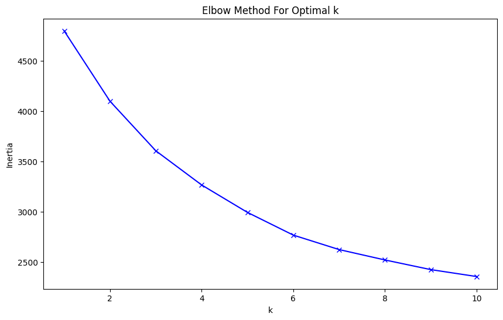

```python
# Create feature matrix
X = df[audio_features]

# Scale the features
scaler = StandardScaler()
X_scaled = scaler.fit_transform(X)

# Elbow method to find optimal number of clusters
inertias = []
K = range(1, 11)
for k in K:
    kmeans = KMeans(n_clusters=k, random_state=42)
    kmeans.fit(X_scaled)
    inertias.append(kmeans.inertia_)



# Plot elbow curve
plt.figure(figsize=(10, 6))
plt.plot(K, inertias, 'bx-')
plt.xlabel('k')
plt.ylabel('Inertia')
plt.title('Elbow Method For Optimal k')
plt.show()
```

Based on the elbow method inertia seems to begin decreasing at 3 so our ideal number of clustering should be 3.

Inertia refers to the sum of squared distances between each data point and the centroid of the cluster to which it belongs. It is a measure of how well the data points are clustered.

```python
features_df = df[audio_features]

scaler = StandardScaler()

features_df_scaled = scaler.fit_transform(features_df)
```

```
For n_clusters = 2, the average silhouette score is : 0.152
```

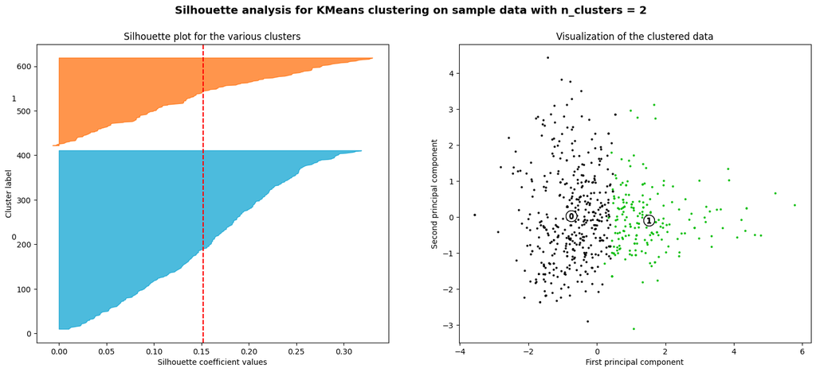

```
For n_clusters = 3, the average silhouette score is : 0.161
```

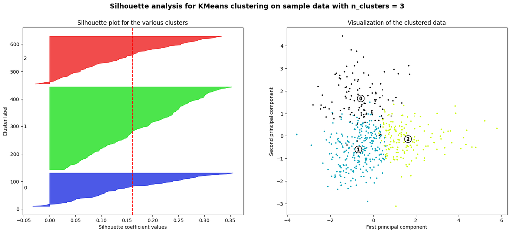

```
For n_clusters = 4, the average silhouette score is : 0.150
```

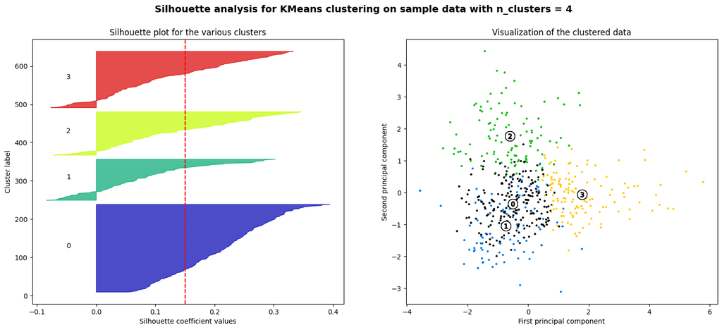

```
For n_clusters = 5, the average silhouette score is : 0.150
```

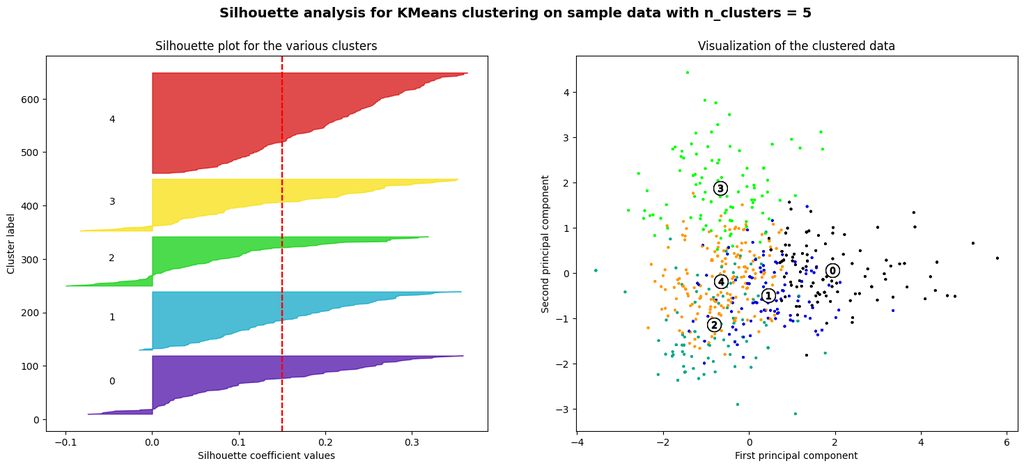

```
For n_clusters = 6, the average silhouette score is : 0.149
```

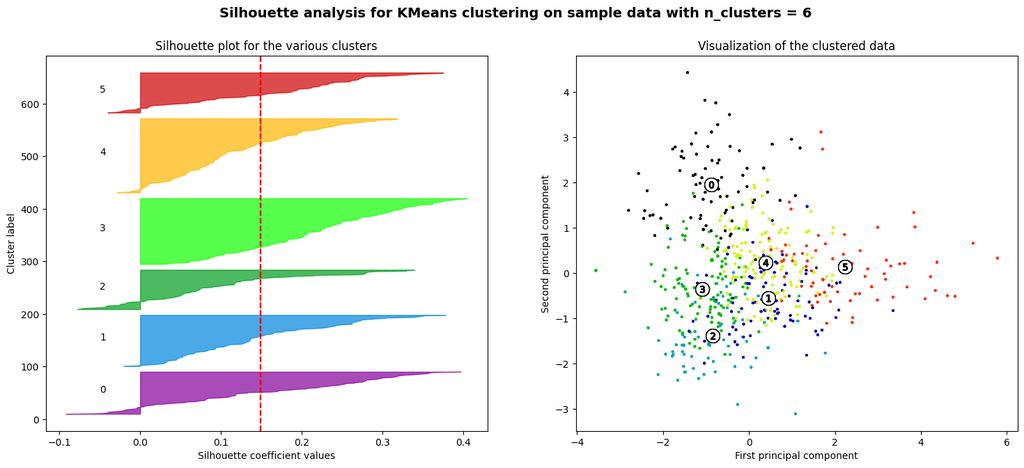

```
For n_clusters = 7, the average silhouette score is : 0.146
```

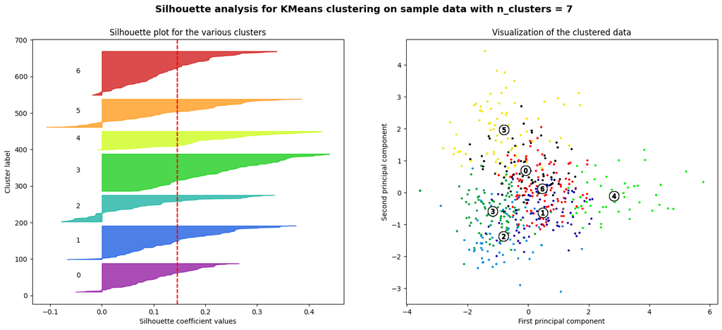

```
For n_clusters = 8, the average silhouette score is : 0.141
```

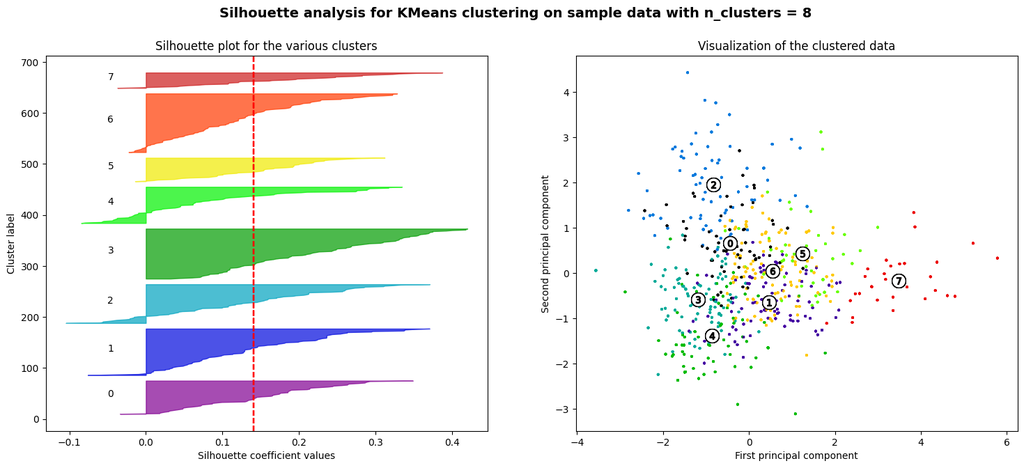

```
For n_clusters = 9, the average silhouette score is : 0.139
```

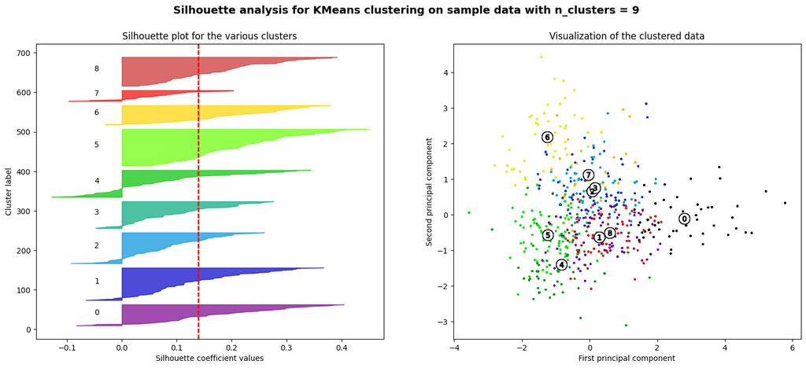

```
For n_clusters = 10, the average silhouette score is : 0.146
```

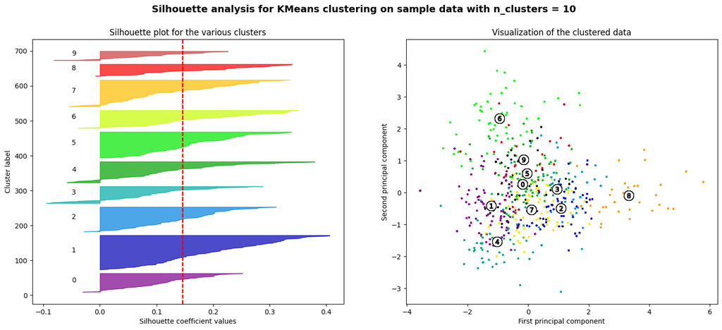

```python
# https://medium.com/@cmukesh8688/silhouette-analysis-in-k-means-clustering-cefa9a7ad111
# perform preliminary K-means clustering for silhouette_score analysis
score_dict = {}
for n_clusters in range(2,11): # Test clusters from 2 - 7
    fig, (ax1, ax2) = plt.subplots(1, 2)
    fig.set_size_inches(18, 7)


    clusterer = KMeans(n_clusters=n_clusters, random_state=632) # Class is 632 oh yea
    cluster_labels = clusterer.fit_predict(features_df_scaled)

    silhouette_avg = silhouette_score(features_df_scaled, cluster_labels)
    print(f"For n_clusters = {n_clusters}, the average silhouette score is : {silhouette_avg:.3f}")

    sample_silhouette_values = silhouette_samples(features_df_scaled, cluster_labels)

    y_lower = 10
    for i in range(n_clusters):
        cluster_silhouette_values = sample_silhouette_values[cluster_labels == i]
        cluster_silhouette_values.sort()
        #print(cluster_silhouette_values)

        size_cluster_i = cluster_silhouette_values.shape[0]
        y_upper = y_lower + size_cluster_i
        #print(y_upper)

        color = cm.nipy_spectral(float(i+.632) / n_clusters)

        #print("This is color:" ,color)
        ax1.fill_betweenx(np.arange(y_lower, y_upper),
                           0, cluster_silhouette_values,
                           facecolor=color, edgecolor=color, alpha=0.7) # provides the fill in the left graphs

        # add labels
        ax1.text(-0.05, y_lower + 0.5 * size_cluster_i, str(i))
        y_lower = y_upper + 10
        ax1.set_title("Silhouette plot for the various clusters")
        ax1.set_xlabel("Silhouette coefficient values")
        ax1.set_ylabel("Cluster label")
        ax1.axvline(x=silhouette_avg, color="red", linestyle="--")


        colors = cm.nipy_spectral(cluster_labels.astype(float) / n_clusters)

        pca = PCA(n_components=2) # reduce dimensionality for easier graphing

        X_pca = pca.fit_transform(features_df_scaled)

        ax2.scatter(X_pca[:, 0], X_pca[:, 1], marker='.', s=30, lw=0, alpha=0.7,
                    c=colors, edgecolor='k')

        centers = pca.transform(clusterer.cluster_centers_)

        ax2.scatter(centers[:, 0], centers[:, 1], marker='o',
                    c="white", alpha=1, s=200, edgecolor='k') # right graphics

        for i, c in enumerate(centers):
            ax2.scatter(c[0], c[1], marker='$%d$' % i, alpha=1,
                        s=50, edgecolor='k') # graph the right graphics

        ax2.set_title("Visualization of the clustered data")
        ax2.set_xlabel("First principal component")
        ax2.set_ylabel("Second principal component")
        plt.suptitle(f"Silhouette analysis for KMeans clustering on sample data with n_clusters = {n_clusters}",
                     fontsize=14, fontweight='bold')

    plt.show()



    score_dict[n_clusters] = silhouette_avg # store to show later
```

```python
score_dict
```

```
{2: 0.15185954098551147,
 3: 0.16079974604326808,
 4: 0.15017223950492342,
 5: 0.15027015287763723,
 6: 0.1490646087490776,
 7: 0.14602256087926344,
 8: 0.14102554275921197,
 9: 0.13947485254965708,
 10: 0.14631305511503623}
```

The highest silhouette score is 0.160 at 3 clusters thus supporting our initial findings with the elbow method. A silhouette score evaluates the quality of clustering by measuring how similar a data point is to points in its own cluster compared to points in other clusters. A higher silhouette score indicates better-defined and more meaningful clusters.

Interpreting Silhouette Scores 1.0: Perfect clustering.

0.7 - 1.0: Strong clustering

0.5 - 0.7: Good clustering.

0.25 - 0.5: Weak clustering.

Below 0.25: Poor clustering

https://en.wikipedia.org/wiki/Silhouette_(clustering)

Based on the information above, we can see that our clustering isn't ideal but it also doesn't take away from trying to find meaningful patterns, so we can continue to evaluate the models further however we have to take the scores and clustering method into consideration when performing our clustering and analysis.

## K-means Model

```python
# Initialize KMeans for k=3 and k=4
kmeans_3 = KMeans(n_clusters=3, random_state=632)

# Fit the models and predict cluster labels
df['three_clusters'] = kmeans_3.fit_predict(features_df_scaled)
```

```python
df["three_clusters"].value_counts()
```

```
1    304
2    174
0    122
Name: three_clusters, dtype: int64
```

### Three Clusters

```python
# Give exmaples of three clusters

display(df[["Rank","Song","Artist","Year"]+audio_features+["loudness","duration_ms","duration_unicode","three_clusters"]][df["three_clusters"] == 0].sort_values("Rank",ascending=True).head(10))
display(df[["Rank","Song","Artist","Year"]+audio_features+["loudness","duration_ms","duration_unicode","three_clusters"]][df["three_clusters"] == 1].sort_values("Rank",ascending=True).head(10))
display(df[["Rank","Song","Artist","Year"]+audio_features+["loudness","duration_ms","duration_unicode","three_clusters"]][df["three_clusters"] == 2].sort_values("Rank",ascending=True).head(10))
```

|  | Rank | Song | Artist | Year | danceability | energy | speechiness | acousticness | liveness | valence | tempo | duration_unicode | loudness | duration_ms | duration_unicode | three_clusters |
| --- | --- | --- | --- | --- | --- | --- | --- | --- | --- | --- | --- | --- | --- | --- | --- | --- |
| 403 | 4 | Bad Guy | Billie Eilish | 2019 | 0.701 | 0.425 | 0.375 | 0.32800 | 0.1000 | 0.562 | 135.128 | 1 | -10.965 | 194088 | 1 | 0 |
| 404 | 5 | Wow. | Post Malone | 2019 | 0.829 | 0.538 | 0.212 | 0.13700 | 0.1030 | 0.389 | 99.952 | 0 | -7.359 | 149547 | 0 | 0 |
| 105 | 6 | First Class | Jack Harlow | 2022 | 0.902 | 0.582 | 0.109 | 0.11100 | 0.1110 | 0.332 | 107.005 | 0 | -5.902 | 173948 | 0 | 0 |
| 406 | 7 | 7 Rings | Ariana Grande | 2019 | 0.777 | 0.317 | 0.308 | 0.59100 | 0.0881 | 0.330 | 139.848 | 1 | -10.732 | 178627 | 1 | 0 |
| 506 | 7 | Life Is Good | Future Featuring Drake | 2020 | 0.676 | 0.609 | 0.481 | 0.07060 | 0.1520 | 0.508 | 142.037 | 2 | -5.831 | 237735 | 2 | 0 |
| 407 | 8 | Talk | Khalid | 2019 | 0.900 | 0.400 | 0.127 | 0.05160 | 0.0599 | 0.346 | 135.984 | 1 | -8.575 | 197573 | 1 | 0 |
| 408 | 9 | Sicko Mode | Travis Scott | 2019 | 0.834 | 0.730 | 0.222 | 0.00513 | 0.1240 | 0.446 | 155.008 | 2 | -3.714 | 312820 | 2 | 0 |
| 108 | 9 | Super Gremlin | Kodak Black | 2022 | 0.825 | 0.414 | 0.144 | 0.00265 | 0.3570 | 0.106 | 72.993 | 1 | -6.634 | 200548 | 1 | 0 |
| 110 | 11 | Wait For U | Future Featuring Drake & Tems | 2022 | 0.463 | 0.642 | 0.340 | 0.31400 | 0.0686 | 0.339 | 83.389 | 1 | -4.474 | 189893 | 1 | 0 |
| 512 | 13 | Whats Poppin | Jack Harlow Featuring DaBaby, Tory Lanez & Lil... | 2020 | 0.923 | 0.604 | 0.245 | 0.01700 | 0.2720 | 0.826 | 145.062 | 0 | -6.671 | 139741 | 0 | 0 |

|  | Rank | Song | Artist | Year | danceability | energy | speechiness | acousticness | liveness | valence | tempo | duration_unicode | loudness | duration_ms | duration_unicode | three_clusters |
| --- | --- | --- | --- | --- | --- | --- | --- | --- | --- | --- | --- | --- | --- | --- | --- | --- |
| 0 | 1 | Levitating | Dua Lipa | 2021 | 0.702 | 0.825 | 0.0601 | 0.00883 | 0.0674 | 0.915 | 102.977 | 1 | -3.787 | 203064 | 1 | 1 |
| 300 | 1 | God's Plan | Drake | 2018 | 0.754 | 0.449 | 0.1090 | 0.03320 | 0.5520 | 0.357 | 77.169 | 1 | -9.211 | 198973 | 1 | 1 |
| 400 | 1 | Old Town Road | Lil Nas X Featuring Billy Ray Cyrus | 2019 | 0.878 | 0.619 | 0.1020 | 0.05330 | 0.1130 | 0.639 | 136.041 | 0 | -5.560 | 157067 | 0 | 1 |
| 500 | 1 | Blinding Lights | The Weeknd | 2020 | 0.513 | 0.730 | 0.0598 | 0.00143 | 0.0897 | 0.334 | 171.001 | 1 | -5.940 | 200040 | 1 | 1 |
| 101 | 2 | As It Was | Harry Styles | 2022 | 0.520 | 0.731 | 0.0557 | 0.34200 | 0.3110 | 0.662 | 173.930 | 0 | -5.338 | 167303 | 0 | 1 |
| 401 | 2 | Sunflower (Spider-Man: Into The Spider-Verse) | Post Malone & Swae Lee | 2019 | 0.755 | 0.522 | 0.0575 | 0.53300 | 0.0685 | 0.925 | 89.960 | 0 | -4.368 | 157560 | 0 | 1 |
| 501 | 2 | Circles | Post Malone | 2020 | 0.695 | 0.763 | 0.0396 | 0.18900 | 0.0863 | 0.551 | 120.042 | 1 | -3.497 | 215280 | 1 | 1 |
| 201 | 2 | Flowers | Miley Cyrus | 2023 | 0.706 | 0.691 | 0.0633 | 0.05840 | 0.0232 | 0.632 | 118.048 | 1 | -4.775 | 200600 | 1 | 1 |
| 1 | 2 | Save Your Tears | The Weeknd & Ariana Grande | 2021 | 0.679 | 0.825 | 0.0309 | 0.02120 | 0.5430 | 0.644 | 118.049 | 1 | -5.487 | 215627 | 1 | 1 |
| 502 | 3 | The Box | Roddy Ricch | 2020 | 0.896 | 0.586 | 0.0559 | 0.10400 | 0.7900 | 0.642 | 116.971 | 1 | -6.687 | 196653 | 1 | 1 |

|  | Rank | Song | Artist | Year | danceability | energy | speechiness | acousticness | liveness | valence | tempo | duration_unicode | loudness | duration_ms | duration_unicode | three_clusters |
| --- | --- | --- | --- | --- | --- | --- | --- | --- | --- | --- | --- | --- | --- | --- | --- | --- |
| 100 | 1 | Heat Waves | Glass Animals | 2022 | 0.761 | 0.525 | 0.0944 | 0.440 | 0.0921 | 0.531 | 80.870 | 2 | -6.900 | 238805 | 2 | 2 |
| 200 | 1 | Last Night | Morgan Wallen | 2023 | 0.492 | 0.673 | 0.0347 | 0.413 | 0.1370 | 0.488 | 203.812 | 0 | -5.431 | 163855 | 0 | 2 |
| 301 | 2 | Perfect | Ed Sheeran | 2018 | 0.599 | 0.448 | 0.0232 | 0.163 | 0.1060 | 0.168 | 95.050 | 2 | -6.312 | 263400 | 2 | 2 |
| 402 | 3 | Without Me | Halsey | 2019 | 0.752 | 0.488 | 0.0705 | 0.293 | 0.0936 | 0.533 | 136.070 | 1 | -7.050 | 201661 | 1 | 2 |
| 103 | 4 | Easy On Me | Adele | 2022 | 0.604 | 0.366 | 0.0282 | 0.578 | 0.1330 | 0.130 | 141.981 | 2 | -7.519 | 224695 | 2 | 2 |
| 303 | 4 | Havana | Camila Cabello Featuring Young Thug | 2018 | 0.765 | 0.523 | 0.0300 | 0.184 | 0.1320 | 0.394 | 104.988 | 2 | -4.333 | 217307 | 2 | 2 |
| 204 | 5 | Creepin' | Metro Boomin, The Weeknd & 21 Savage | 2023 | 0.716 | 0.613 | 0.0522 | 0.391 | 0.0813 | 0.157 | 97.914 | 2 | -6.018 | 221520 | 2 | 2 |
| 304 | 5 | Rockstar | Post Malone Featuring 21 Savage | 2018 | 0.585 | 0.520 | 0.0713 | 0.124 | 0.1310 | 0.129 | 159.798 | 2 | -6.136 | 218147 | 2 | 2 |
| 305 | 6 | Psycho | Post Malone Featuring Ty Dolla $ign | 2018 | 0.750 | 0.560 | 0.1050 | 0.546 | 0.1110 | 0.459 | 140.060 | 2 | -8.094 | 221440 | 2 | 2 |
| 206 | 7 | Die For You | The Weeknd & Ariana Grande | 2023 | 0.586 | 0.525 | 0.0615 | 0.111 | 0.1340 | 0.508 | 133.629 | 2 | -7.163 | 260253 | 2 | 2 |

```python
display(df[["three_clusters","Rank"]+audio_features+["loudness","duration_ms","duration_unicode"]].groupby("three_clusters").mean())
display(df[["three_clusters","Rank"]+audio_features+["loudness","duration_ms","duration_unicode"]].groupby("three_clusters").median())
```

| three_clusters | Rank | danceability | energy | speechiness | acousticness | liveness | valence | tempo | duration_unicode | loudness | duration_ms | duration_unicode |
| --- | --- | --- | --- | --- | --- | --- | --- | --- | --- | --- | --- | --- |
| 0 | 52.688525 | 0.783869 | 0.585484 | 0.296075 | 0.126331 | 0.135901 | 0.450049 | 128.190303 | 0.975410 | -6.876484 | 198183.237705 | 0.975410 |
| 1 | 49.746711 | 0.700089 | 0.701382 | 0.069311 | 0.129436 | 0.197846 | 0.591075 | 118.222714 | 0.891447 | -5.446622 | 192592.273026 | 0.891447 |
| 2 | 50.281609 | 0.594391 | 0.505667 | 0.060774 | 0.435398 | 0.146720 | 0.362382 | 122.699466 | 1.206897 | -7.463109 | 210440.063218 | 1.206897 |

| three_clusters | Rank | danceability | energy | speechiness | acousticness | liveness | valence | tempo | duration_unicode | loudness | duration_ms | duration_unicode |
| --- | --- | --- | --- | --- | --- | --- | --- | --- | --- | --- | --- | --- |
| 0 | 50.5 | 0.8230 | 0.586 | 0.2910 | 0.0635 | 0.1110 | 0.4245 | 130.7585 | 1.0 | -6.4950 | 193049.5 | 1.0 |
| 1 | 49.5 | 0.7065 | 0.709 | 0.0555 | 0.0896 | 0.1340 | 0.5940 | 116.8330 | 1.0 | -5.3635 | 193327.0 | 1.0 |
| 2 | 52.0 | 0.5965 | 0.525 | 0.0428 | 0.4220 | 0.1125 | 0.3500 | 124.0155 | 1.0 | -7.0930 | 209056.5 | 1.0 |

## Dashboards and Visualizations:

### Tableau Dashboard

[Link To Dashboard](https://public.tableau.com/views/final_viz_17331928761890/Story1?:language=en-US&:sid=&:redirect=auth&:display_count=n&:origin=viz_share_link)

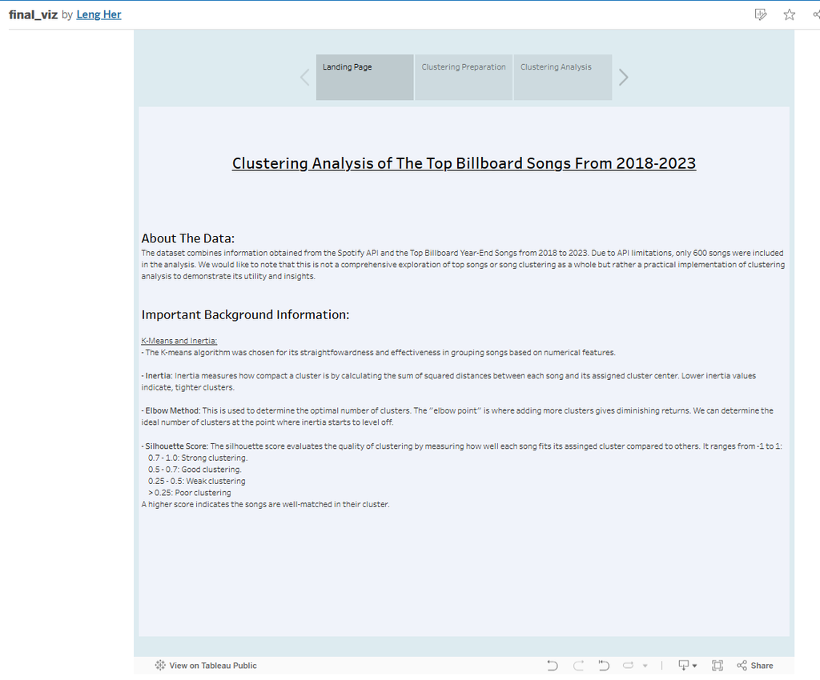

## Conclusions and Findings:

After some analysis we also noticed that the average Billboard rank across the clusters were relatively close. This suggests that popularity is not driven by audio features, but instead other factors such as marketing, social media trends, and artist popularity among other factors. Another important factor is that the audience is diverse which leads to a diverse set of songs among the top songs. Although audio features may reveal interesting patterns but alone they may not tell the whole story about song performance.

In conclusion, this analysis showcases a practical analysis and use of clustering to understand similarities and differences in top songs throughout the years. While audio features may tell us interesting patterns about each song within their cluster it doesn't tell the full story which can be reflected in the silhouette score. Potentially, adding more features and selecting features that determine most of the variance can lead to better clustering, and understanding of the similarities and differences between the most successful music.